# Logistics Practice

Jinwoo Chung

## Table of Contents

1. Separating Train and Test Data
2. Plotting
3. Logistic Regression Model
4. Creating Confusion Matrix
5. ROC and AUC
6. Repeated Cross Validation
7. Repeated Cross Validation Confusion Matrix

### Basic Setup

```r
library(pacman)
pacman::p_load(data.table,dplyr,caret,ROCR)
main <- as.data.frame(data.table::fread("https://raw.githubusercontent.com/Jinwooooo/fcdc-ml-practice/master/data/01_heights_weights_genders.csv"))
# due to NA values, need to either insert mean values instead or exclude them (in this case, will use the former)
main$Height[is.na(main$Height)] <- mean(main$Height, na.rm=T)
main$Weight[is.na(main$Weight)] <- mean(main$Weight, na.rm=T)
# due to Gender values being a character value, reformatting them into a factor for regression
main$Gender <- ifelse(main$Gender=='Male', 0, 1)
```

### 1. Separating Train and Test Data

```r
# setting seed
set.seed(33)
# splitting data
index.train <- sample(1:nrow(main), round(nrow(main) * 0.8))
train <- main[index.train, ]
test <- main[-index.train, ]
# looking at the overall data
glimpse(train)
```

```
## Observations: 8,000
## Variables: 3
## $ Gender <dbl> 0, 0, 0, 1, 1, 1, 0, 0, 0, 0, 1, 0, 0, 0, 1, 1, 1, 0, 0...
## $ Height <dbl> 72.38610, 70.46662, 71.17115, 66.75098, 65.70658, 66.25...
## $ Weight <dbl> 212.21252, 187.28325, 213.45723, 168.43594, 149.71582, ...
```

### 2. Plotting

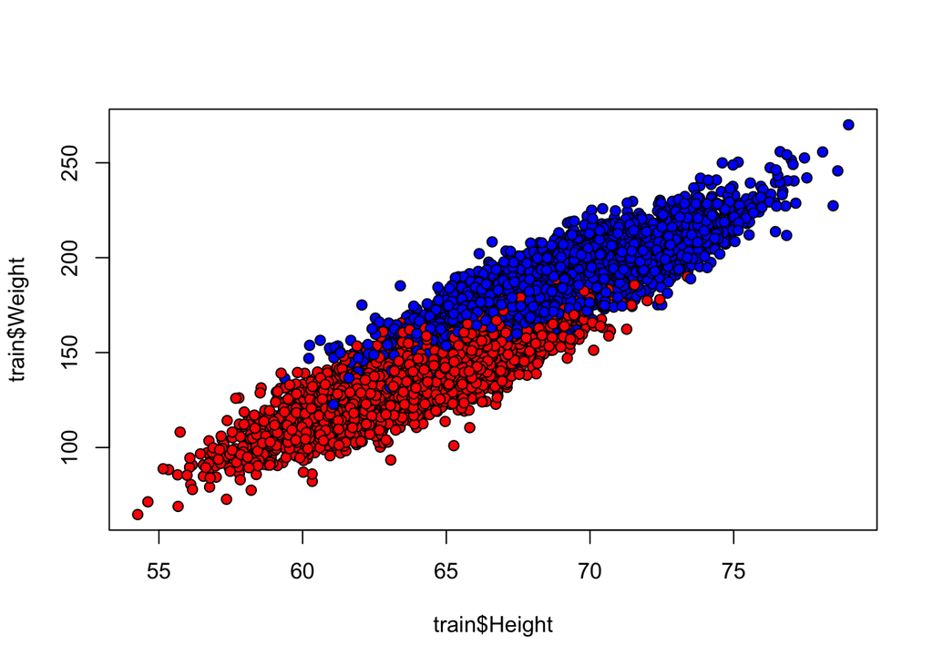

```r
# Plotting (pch is one of the theme of the graphs)
plot(train$Height, train$Weight, pch=21, bg=c('blue','red')[train$Gender+1])
```

### 3. Logistic Regression Model

```r
# Using Logistic Reg because the Gender is value 0/1
glm.train <- glm(Gender ~ ., family=binomial(link='logit'), data=train)
summary(glm.train)
```

```
##
## Call:
## glm(formula = Gender ~ ., family = binomial(link = "logit"),
##     data = train)
##
## Deviance Residuals:
##     Min       1Q   Median       3Q      Max
## -3.6073  -0.2143  -0.0079   0.2130   3.1112
##
## Coefficients:
##              Estimate Std. Error z value Pr(>|z|)
## (Intercept) -0.971379   1.473222  -0.659     0.51
## Height       0.500767   0.032172  15.565   <2e-16 ***
## Weight      -0.199823   0.005751 -34.745   <2e-16 ***
## ---
## Signif. codes:  0 '***' 0.001 '**' 0.01 '*' 0.05 '.' 0.1 ' ' 1
##
## (Dispersion parameter for binomial family taken to be 1)
##
##     Null deviance: 11089.5  on 7999  degrees of freedom
## Residual deviance:  3338.5  on 7997  degrees of freedom
## AIC: 3344.5
##
## Number of Fisher Scoring iterations: 7
```

### 4. Creating Confusion Matrix

```r
# predicting what the test Genders are with [Height and Weight]
prediction <- predict(glm.train, newdata = test, type = "response")
# because it is a regression (equation), it will return values between 0~1 (not binary)
# manually splitting data into 0 and 1 (male/female in this case), to see how well it predicted
prediction.bin <- ifelse(prediction > 0.5, 1, 0)
# confusion Matrix is used to usually see if the regression is overfitting the data points
caret::confusionMatrix(as.factor(prediction.bin), reference = as.factor(prediction.bin))
```

```
## Confusion Matrix and Statistics
##
##           Reference
## Prediction    0    1
##          0  936    0
##          1    0 1064
##
##                Accuracy : 1
##                  95% CI : (0.9982, 1)
##     No Information Rate : 0.532
##     P-Value [Acc > NIR] : < 2.2e-16
##
##                   Kappa : 1
##  Mcnemar's Test P-Value : NA
##
##             Sensitivity : 1.000
##             Specificity : 1.000
##          Pos Pred Value : 1.000
##          Neg Pred Value : 1.000
##              Prevalence : 0.468
##          Detection Rate : 0.468
##    Detection Prevalence : 0.468
##       Balanced Accuracy : 1.000
##
##        'Positive' Class : 0
##
```

### 5. ROC and AUC

**ROC (Receiver Operating Characteristics)** - ROC is used to see visually how well the prediction went

- if it is close to a linear from origin to the top right corner, it means the model is as bad as just randomly guessing
- if it is close to a log curve, it means model is better than just randomly guessing
- if it is close to a exponential curve, it means the model is predicting values the opposite of what the true value is

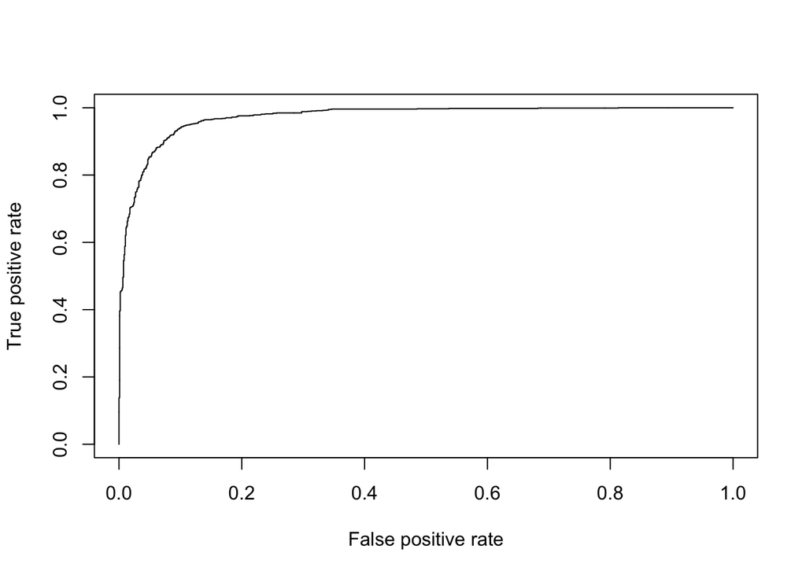

```r
# ** note that if you just inverse the output of a exponential curve, it is same as a log curve overall **
prediction.roc <- predict(glm.train, newdata=test, type='response')
prediction.standardized <- ROCR::prediction(prediction.roc, test$Gender)
prediction.performance <- ROCR::performance(prediction.standardized, measure='tpr', x.measure='fpr')
plot(prediction.performance)
```

**AUC (Area Under the Curve)** - AUC is used as the same purpose as ROC, but in numbers instead

- if it is close to 0.5, it means the model is as bad as just randomly guessing
- if it s close to 1, it means the model better than just randmoly guessing
- if it s less than 0.5, inverse the predicting values (as mentioned before)

```r
auc <- performance(prediction.standardized, measure='auc')
# @ for class is $ for list
auc <- auc@y.values[[1]]
auc
```

```
## [1] 0.9725135
```

### 6. Repeated Cross Validation (use caret package for efficiency)

Cross Validation is crucial to know that the model robust (i.e. not heavily affected by sample/train data).

The mose general Cross Validation Techniques are:

- k-fold cross validation (which is done here, k = 10 and repated 5 times)
- leave-p-out cross validation (this is more of a brute force technique)

```r
control <- caret::trainControl(method="repeatedcv", number=10, repeats=5)
glm.cv.gender <- caret::train(as.factor(Gender) ~ .,
               data=train, method="glm", na.action=na.omit,
               family=binomial(link='logit'), trControl=control)
print(glm.cv.gender)
```

```
## Generalized Linear Model
##
## 8000 samples
##    2 predictor
##    2 classes: '0', '1'
##
## No pre-processing
## Resampling: Cross-Validated (10 fold, repeated 5 times)
## Summary of sample sizes: 7201, 7200, 7200, 7201, 7200, 7200, ...
## Resampling results:
##
##   Accuracy  Kappa
##   0.918626  0.837225
```

### 7. Repeated Cross Validation Confusion Matrix

```r
predict.cv.gender <- predict(glm.cv.gender, test, type = "raw", na.action = na.pass)
confusionMatrix(as.factor(predict.cv.gender), as.factor(test$Gender))
```

```
## Confusion Matrix and Statistics
##
##           Reference
## Prediction   0   1
##          0 867  69
##          1  91 973
##
##                Accuracy : 0.92
##                  95% CI : (0.9072, 0.9315)
##     No Information Rate : 0.521
##     P-Value [Acc > NIR] : < 2e-16
##
##                   Kappa : 0.8396
##  Mcnemar's Test P-Value : 0.09688
##
##             Sensitivity : 0.9050
##             Specificity : 0.9338
##          Pos Pred Value : 0.9263
##          Neg Pred Value : 0.9145
##              Prevalence : 0.4790
##          Detection Rate : 0.4335
##    Detection Prevalence : 0.4680
##       Balanced Accuracy : 0.9194
##
##        'Positive' Class : 0
##
```